# Redd Distribution and Stream Temperature Evaluations for Multiple Reach Assessments

Mike Ackerman, Richie Carmichael, and Kevin See

February 19, 2020

<sup>1</sup> Biomark, Inc.

# 1 Introduction

The Bureau of Reclamation (BOR), Idaho Governor’s Office of Species Conservation (OSC), and an interdisciplinary team of partners have assembled an Upper Salmon Assessment Team to complete biologic and geomorphic analyses in support of future project identification, prioritization, and design in the Upper Salmon Subbasin, Idaho targeted at improving stream and riparian habitat to support imperiled Chinook salmon and steelhead populations. The biologic and geomorphic analyses are being lead by Biomark, Inc. (Biomark) and Rio Applied Science and Engineering (Rio ASE), respectively. Past efforts from the team resulted in the development of a watershed-scale Integrated Rehabilitation Assessment (IRA; Idaho OSC Team 2019) in the Lemhi, Pahsimeroi, and Upper Salmon (Sawtooth Valley) watersheds. This inital phase of the project identified the “problem” by spatially quantifying capacity limitation for spring/summer chinook salmon and summer run steelhead within a geomorphic context across these threee watersheds. The second phase, termed the Multiple Reach Assessments (MRA), includes identifying appropriate and focused “solutions” to the identified capacity problems within four valley segments: Upper Lemhi, Lower Lemhi, Lower Pahsimeroi,a nd Upper Salmon (Decker Flats). To achieve this goal, the team will collaboratively summarize existing and targeted physical habitat conditions relative to document habitat needs for specific species and life stages, including discussion of high-quality habitat, its creation, and its maintenance to inform future rehabilitation actions.

In the IRA, we determined that available spawning habitat (i.e., redd capacity) was not limiting in any of the target watersheds (Lemhi River, Pahsimeroi River, and upper Salmon River above Redfish Lake Creek) for either Chinook salmon or steelhead. Available spawning capacity was estimated as the total number of redds that each watershed could support and was estimated using quantile regression forest (QRF; Idaho OSC Team 2019, Appendix B) models and the number of redds required to support contemporary escapement or escapement to support recovery goals (e.g., minimum abundance thresholds [MAT]) was estimated using a generalized capacity model (Idaho OSC Team 2019, Appendix C). It was instead concluded that juvenile rearing habitat, during both summer and winter months, was likely limiting productivity of Chinook salmon and steelhead populations in target watersheds. Additionally, life stages not evaluated there (e.g., incubation, fry) may contribute to limited productivity in these populations. With that said, we acknowledge that future habitat actions in the target watershed should attempt to take a “do no harm” approach and minimize any negative impacts to available spawning habitat, especially in existing core spawning areas. But we believe that any appropriate actions to improve juvenile rearing will likely cause minimal or no negative impacts to spawning habitat, especially if habitat complexity (e.g., increased pool frequency with following pool-tail, riffle sequences) is considered. Additionally, if was stated in the IRA that *“providing sufficient adult holding (prespawn) habitat should be considered and would be provided by increased habitat complexity”*. Within the Lemhi, Pahsimeroi, and Upper Salmon watersheds, Chinook salmon may hold in reaches downstream or near the spawning areas in late-July and August prior to the spawning season, a time where high stream temperatures can be problematic. And finally, the Idaho OSC Team found that *"spawning habitat historically occurred farther upstream than current core ares, especially in the Upper Salmon River headwaters, effectively reducing the area currently available for rearing (i.e., area downstream of spawning).* One of the goals of this evaluation is to document the location and distribution of spawning redds in the target watersheds for recent years in which redd surveys were completed and data are available. Redd survey data were made available by the Idaho Department of Fish and Game (IDFG). Here, modeled stream temperatures available from McNyset et al. (2015) are compared to recent redd density data to determine whether temperatures are appropriate or perhaps problematic in those areas; we can also consider areas that may have historically been used for spawning.

In Appendix A of the IRA report (Idaho OSC Team 2019), we used a combination of modeled temperature predictions (McNyset et al. 2015) and life-stage-specific temperature thresholds (Carter 2005) to evaluate whether current water temperatures might limit the ability of spring-summer run Chinook and summer run steelhead to use available habitat in the Lemhi, Pahsimeroi, and Upper Salmon watersheds. In addition, a simple warming scenario was presented (added 3°C to contemporary modeled temperatures) to describe potential increases in stream temperature expected to result from climate change to assess whether the implementation of restoration actions to reduce temperatures may be necessary to aid recovery of Chinook salmon and steelhead in the watersheds. The following are the key findings from that temperature and climate change assessment:

## 1.1 Lemhi River

### 1.1.1 Chinook salmon

Under current conditions, winter and early-spring modeled stream temperatures were below optimum values during egg incubation, fry emergence, juvenile winter rearing, and spring smolt emigration; this can potentially slow incubation and emergence resulting in fry emergence occurring during sub-optimal timing. Low temperatures during winter months can also cease presmolt growth or condition during winter months. Modeled summer temperatures exceed optimum values at times, potentially increasing stress during adult holding and elevating food requirements for summer parr. Under an assumed 3°C increase scenario, winter and spring condtions improved somewhat, but conditions worsen for summer parr and spawners with temperatures exceeding maximum thresholds for Chinook salmon in excess of 50% of the time.

### 1.1.2 Steelhead

Under current conditions, winter and early-spring modeled water temperatures were below optimum values for juvenile rearing and spring emigration, likely reducing juvenile growth and condition factors during winter months. Under the assumed 3°C increase scenario, conditions improved for winter and spring life stages; however, conditions worsed during late-spring and summer with temperatures exceeding maximum temperature thresholds for summer juvenile rearing across much of the watershed.

## 1.2 Pahsimeroi

### 1.2.1 Chinook salmon

Under current conditions, stream temperatures in the Pahsimeroi River are rarely below optimum values. However, spring and summer temperatures tend to exceed optimum values for extended periods, potentially increasing stress on adults during staging (holding) and spawning. High spring and summer temperatures can also increase stress during incubation and emergence and increase food requirements for spring smolts and summer parr, potentially decreasing body condition. Under the assumed 3°C increase scenario, conditions worsened for all summer life stages, with water temperatures above optimum for a majority of the time and potentially surpassing acute (lethal) temperatures for holding and spawning adults.

### 1.2.2 Steelhead

Although current modeled water temperatures in the Pahsimeroi River seem to be okay for most life stages evaluated, conditons worsen under the 3°C increase scenario with temperatures above optimum, maximum, or acute thresholds during spawining, incubation, emergence, spring smolt emigration, and summer parr rearing life stages.

## 1.3 Upper Salmon

### 1.3.1 Chinook salmon

Under current conditions, modeled stream temperatures are generally within optimum temperatures for each of the life stages evaluated; however, under the 3°C increase scenario conditions again worsen for summer life stages including adult holding and spawning and parr rearing.

### 1.3.2 Steelhead

Similar to Chinook salmon, modeled stream temperatures are generally within optimum temperatures for each of the life stages evaluated under current conditions. And again, most notably, under the 3°C increase scenario, summer water temperatures potentially increase to above maximum during portions of spawning and summer parr rearing.

## 1.4 Overall Life Stage Specific Temperature Findings from IRA

Not surprisingly, problematic stream temperature condtions were primarily identified during the extreme seasons, winter and summer. During winter and under current conditons, stream temperatures are often below optimum temperatures for juvenile winter rearing. This can results in no growth or loss of body condition prior to the spring emigration season. During summer, modeled stream temperatures were often above optimum or maximum thresholds for adult holding and spawning or summer rearing. Summer conditions worsened under the simple climate change scenario in all cases. High temperatures for adults can result in prespawn mortality or increased stress during spawning behavior. High temperatures for parr increases food requirements which increases energy expenditure to search for food and decreased growth and body conditon, potentially leading to decreased survival during fall or winter months, or forcing individuals to emigrate downstream in search for more optimal fall and winter rearing.

## 1.5 Objectives

We document the location and distribution of Chinook salmon spawning in the target watersheds and compare redd density summaries to available modeled temperature results. The goal is to make available the distribution of contemporary core spawning areas, examine temperatures in those areas, and examine historic spawning areas, in a spatially explicit (i.e., by river kilometer [rkm]) framework.

Further, we want to examine stream temperatures during critical life stages for Chinook salmon and steelhead in each of the three watersheds (Lemhi, Pahsimeroi, Upper Salmon) and how they compare to temperature thresholds for those species from Carter (2005) in a spatially-explicit manner. By doing this evaluation by rkm, we can identify particular reaches within the watersheds where stream temperatures may be limiting, particularly during winter (juvenile winter rearing) and summer (adult holding, spawning, parr rearing) months identified as problematic in the IRA (Idaho OSC Team 2019).

# 2 Methods

## 2.1 Data Sources

All data and R code used in this analysis can be found in the `mra_redds_norwest` repository located at https://github.com/rcarmichael3/mra_redds_norwest. The following data sources are used here:

### 2.1.1 Redds

Chinook salmon redd location data were provided to us by IDFG from redd surveys completed in each of the three watersheds. For the Lemhi River, redd survey data were available for 2004 to 2018. Redd data for the Pahsimeroi River were available for 2009 to 2018; finally, Upper Salmon redd data were available for 2010 to 2018.

### 2.1.2 River Kilometer

- Lemhi River: The confluence of Eighteenmile and Texas Creeks near the Highway 29 bridge in Leadore.
- Pahsimeroi River: The confluence of the West Fork and East Fork Pahsimeroi River.
- Upper Salmon River: The origin of the Salmon River.

### 2.1.3 Temperature

#### 2.1.3.1 Spatially, Temporally Continuous Modeled Temperature

Spatially and temporally continuous predictions of stream temperatures were available for the three watersheds from a model described in McNyset et al. (2015).The models uses land surface temperautre (LST) data from the U.S. National Aeronautics and Space Administration’s (NASA) Moderate Resolution Imaging Spectroradiometer (MODIS) satellite sensor. The LST data are available daily at a resolution of 1 square kilometer and are summarized over an 8-day NASA “week”. Model results were available for each of the watersheds for the following years:

- Lemhi River: 2011, 2012, 2013, 2014, 2015
- Pahsimeroi River: 2011, 2013
- Upper Salmon River: 2011, 2013

Predictions were available at 8-day intervals and were calculated as the mean of 8-day daily maximum temperatures along stream networks within the three watersheds.

#### 2.1.3.2 NorWeST Temperature

Additionally, stream temperature data were downloaded from the NorWeST webpage https://www.fs.fed.us/rm/boise/AWAE/projects/NorWeST.html and are described by Isaak et al. (2017). Briefly, the NorWeST page hosts various stream temperature historic and future climate scenario datasets at 1-km resolution for streams throughout the Pacific Northwest. We describe scenarios used here further below.

#### 2.1.3.3 Life-Stage Temperature Thresholds

Finally, life-stage specific temperature criteria were adopted from Carter (2005) in addition to transition timing of local Chinook salmon and steelhead life stages (USBWP 2004; Personal Communication, Jude Trapani, Bureau of Reclamation; Personal Communication, Mike Edmondson, Idaho Office of Species Conservation; and Personal Communication, Mike Ackerman, Biomark, Inc., Applied Biological Services) to identify minimum, optimal, maximum, and acute temperature thresholds for various life stages of Chinook salmon and steelhead. Temperature thresholds and seasonal timing for Chinook salmon and steelhead are presented in Tables A-1 and A-2 in Appendix A of the IRA (Idaho OSC Team 2019).

## 2.2 Analysis

We describe detailed methods for visualization of redd distribution, stream temperature, river kilometer, and life-stage specific temperature thresholds here for a single watershed. Methods were then similarly applied across each of the watersheds: Lemhi River, Pahsimeroi River, Upper Salmon River (above Redfish Lake Creek).

### 2.2.1 Chinook Salmon Redds

1. The spatially, temporally continuous temperature predictions dataset was filtered to only include predictions for a given watershed (e.g., Lemhi) and then we selected predictions for a julian date within the peak of the spawning season.
2. River kilometer points were joined to the temperature dataset to assign the spatially continuous temperature predictions to an rkm.
3. Temperature predictions were average within rkms and across years for which data were available.
4. Redd locations were joined to the spatially continuous temperature predictions and plotted to show the distribution of redds within a watershed along with the mean of 8-day maximum temperature predictions.
5. Redd locations were also plotted by survey year to show potential changes in the distribution of redds over time.
6. Additionally, rkm points were attached to the redd location data to assign each redd to an rkm.
7. Redd density was calculated as the number of redds per rkm for each year and then averaged across years.
8. Redd densities, by rkm, were plotted with a longitudinal temperature profile to visualize modeled stream densities where redd densities are highest (or vice-versa).

These plots provide a summary of the current (existing) distribution of Chinook salmon redds in the three watersheds and whether those redds fall within temperatures appropriate for adult holding or spawning. Additionally, we can consider the potential historic distribution of Chinook salmon spawning in those areas. Finally, we, at least initially, present temperature predictions for August 29, here, but the framework allows us to present any historic, contemporary, or future climate change scenario and using either the spatially, temporally continuous dataset (McNyset et al. 2015) or data from NorWeST (Isaak et al. 2017).

### 2.2.2 Life Stage Specific Longitudinal Temperature Profiles

1. As before, river kilometer points were joined to the temperature dataset to assign the spatially continuous temperature predictions to an rkm. But here, we still have predictions for all 8-day intervals within the calendar year.
2. For each watershed, temperature predictions were averaged within rkms and across years to provide the mean of 8-day maximum predictions by rkm and 8-day interval.
3. For a given life-stage we filtered the dataset to only include data within the time period for that life stage and then calculated the mean, minimum, and maximum temperature predictions across that time period.
4. We then plotted a longitudinal temperature profile by watershed, species, and life stage showing the mean, minimum, and maximum temperature predictions for the time interval within the given species x life stage combination.
5. With the longitudinal temperature profile, we plotted the minimum, optimum, maximum, and acute temperature thresholds from Carter (2005) for the given species and life stage.

This evaluation builds on results presented in Appendix A in the IRA in that it provides a more spatially explicit summary of longitudinal temperature profiles and whether minimum, mean, and maximum stream temperatures fall within or outside of optimum temperatures by species and life stage. We can also identify particular rkms where temperatures fall outside of optimum or other temperature thresholds for sensitive life stages. And as above, the framework will allow us to assess any available historic, contemporary, or potential future scenario. With that said, NorWeST data is targeted towards summer stream temperatures, and thus, could also be summarized for summer life stages (e.g., adult holding and spawning [Chinook only], summer parr).

# 3 Results

## 3.1 Lemhi River

### 3.1.1 Chinook Salmon Redds

The distribution of Chinook salmon redd locations in the Lemhi River for years in which survey data were available, along with predictions of the mean of 8-day maximum temperatures for August 29 are shown in Figures 3.1 and 3.2.

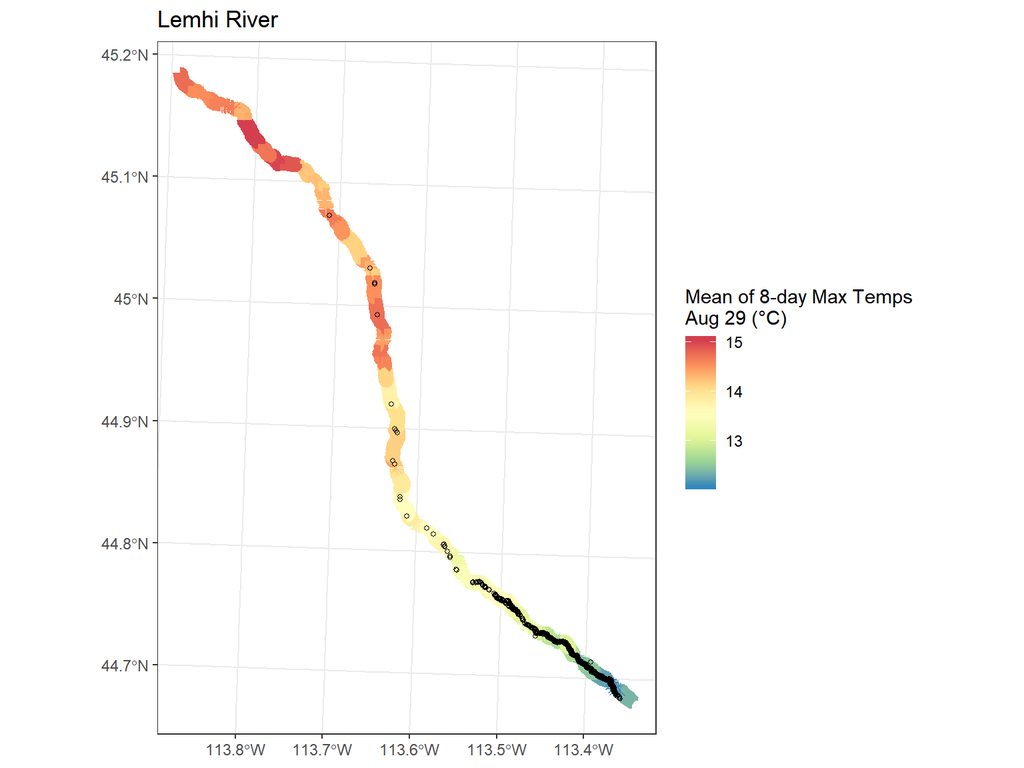

Figure 3.1: Map of Lemhi River showing modeled stream temperatures near the late summer spawning season for Chinook salmon and the distribution of redds (small, open black circles) available from redd surveys in recent years. Modeled temperatures are predictions for August 29 averaged across years where predictions are available.

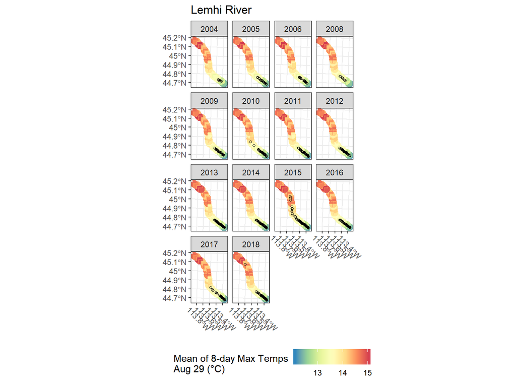

Figure 3.2: Same as figure above, except faceted by survey year to show years for which data are available and how the distribution of redds potentially changed.

Figure 3.3 provides a longitudinal temperature profile, in this case the mean of 8-day maximum temperature predictions for August 29, along with mean redd densities averaged across years for which survey data were available.

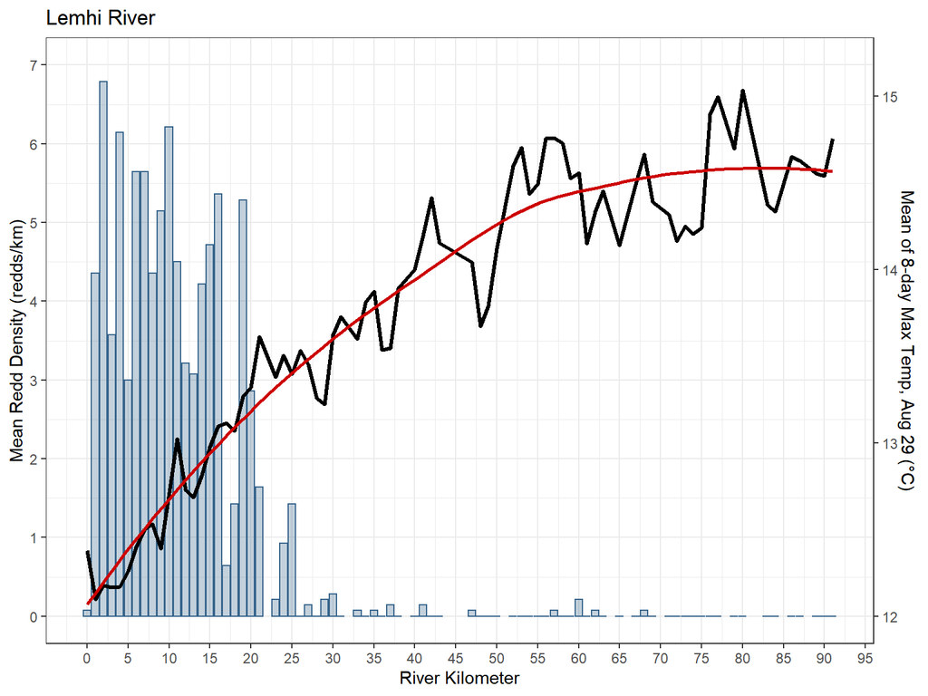

Figure 3.3: Mean redd density (redds/km) by river kilometer in the Lemhi River averaged across years for which surveys were completed and data available. River kilometer 0 is the upstream extent of the mainstem Lemhi River and occurs at the Highway 29 bridge near Leadore and the confluence of Eighteenmile and Texas Creeks. River kilometer 91 is at the confluence with the Salmon River. A longitudinal temperature profile, with smoothed line (red), showing predictions of the mean of 8-day maximum temperatures at August 29 (averaged across available years) is also shown.

### 3.1.2 Life Stage Specific Longitudinal Temperature Profiles

#### 3.1.2.1 Chinook salmon

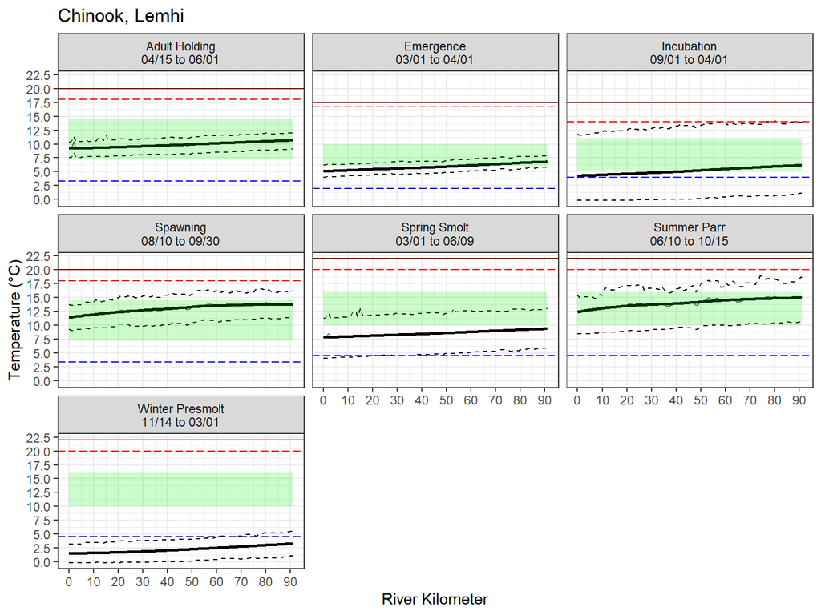

#### 3.1.2.2 Steelhead

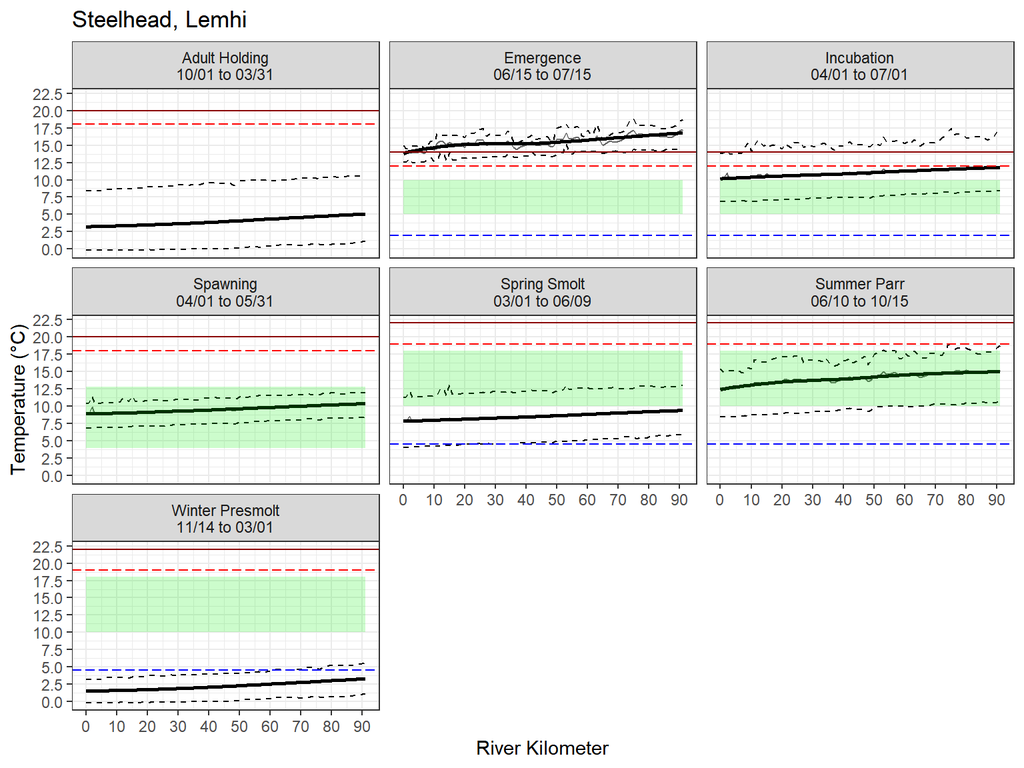

## 3.2 Pahsimeroi River

### 3.2.1 Chinook Salmon Redds

The distribution of Chinook salmon redd locations in the Pahsimeroi River for years in which survey data were available, along with predictions of the mean of 8-day maximum temperatures for August 29 are shown in Figures 3.6 and 3.7.

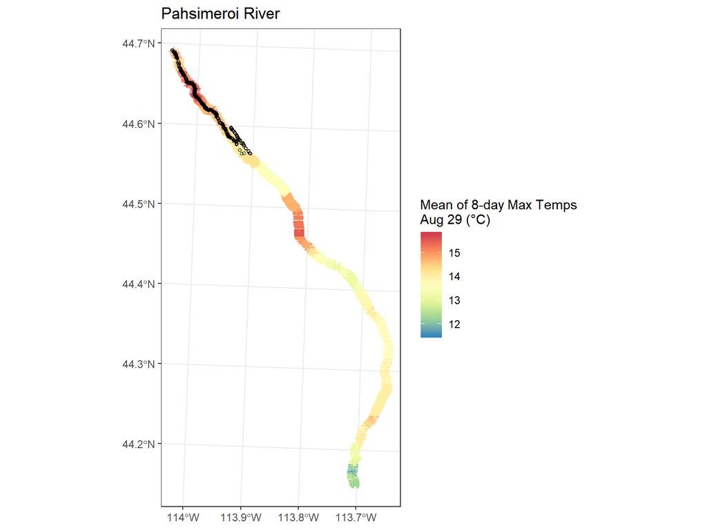

Figure 3.6: Map of Pahsimeroi River showing modeled stream temperatures near the late summer spawning season for Chinook salmon and the distribution of redds (small, open black circles) available from redd surveys in recent years. Modeled temperatures are predictions for August 29 averaged across years where predictions are available.

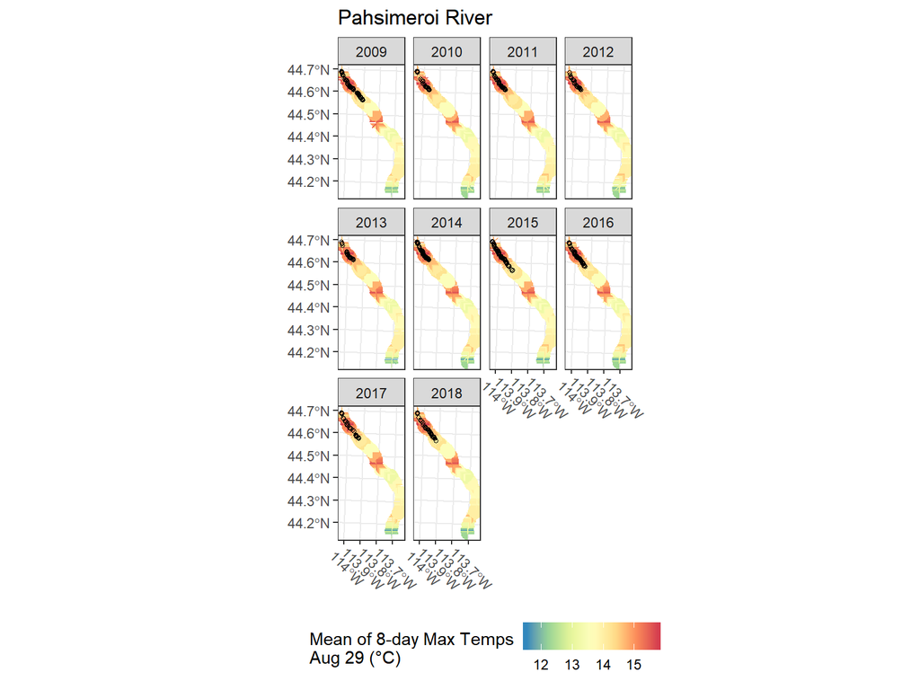

Figure 3.7: Same as figure above, except faceted by survey year to show years for which data are available and how the distribution of redds potentially changed.

Figure 3.8 provides a longitudinal temperature profile, in this case the mean of 8-day maximum temperature predictions for August 29, along with mean redd densities averaged across years for which survey data were available.

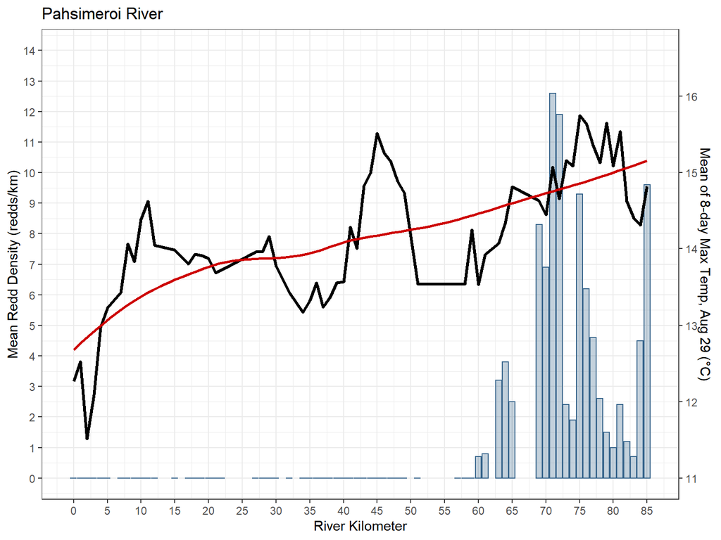

Figure 3.8: Mean redd density (redds/km) by river kilometer in the Pahsimeroi River averaged across years for which surveys were completed and data available. River kilometer 0 is the upstream extent of the mainstem Pahsimeroi River and occurs at the confluence of the West Fork and East Fork Pahsimeroi River. River kilometer 85, the downstream extent is at the confluence with the Salmon River. A longitudinal temperature profile, with smoothed line (red), showing predictions of the mean of 8-day maximum temperatures at August 29 (averaged across available years) is also shown.

### 3.2.2 Life Stage Specific Longitudinal Temperature Profiles

#### 3.2.2.1 Chinook salmon

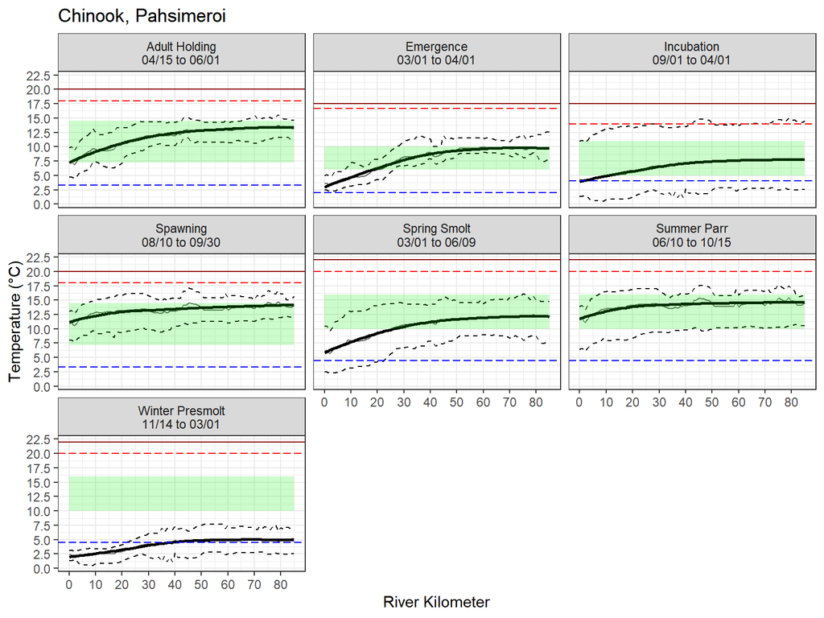

Figure 3.9: Longitudinal temperature profiles for the mainstem Pahsimeroi River faceted by Chinook salmon life stage. The bold black line shows the mean of 8-day max temperatures among dates within the life stage and dashed black lines show the minumum and maximum 8-day values among those dates. The green ribbon shows the optimum temperature range for that life stage whereas the blue line shows the minimum temperature threshold and the red dashed and solid lines show maximum and acute temperature thresholds, respectively, for each life stage.

#### 3.2.2.2 Steelhead

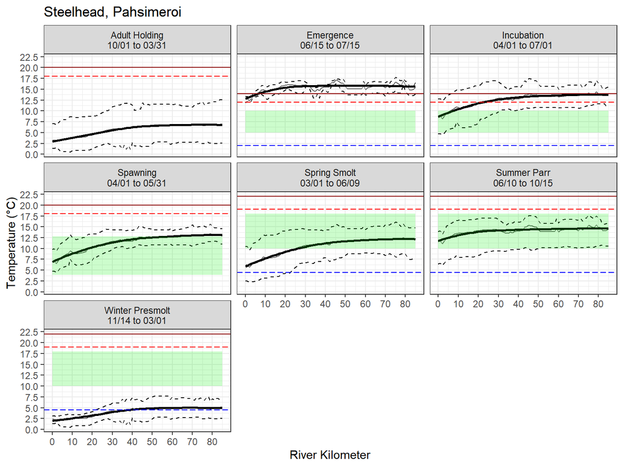

Figure 3.10: Longitudinal temperature profiles for the mainstem Pahsimeroi River faceted by steelhead life stage. The bold black line shows the mean of 8-day max temperatures among dates within the life stage and dashed black lines show the minumum and maximum 8-day values among those dates. The green ribbon shows the optimum temperature range for that life stage whereas the blue line shows the minimum temperature threshold and the red dashed and solid lines show maximum and acute temperature thresholds, respectively, for each life stage.

## 3.3 Upper Salmon River

### 3.3.1 Chinook Salmon Redds

The distribution of Chinook salmon redd locations in the Upper Salmon River (above Redfish Lake Creek) for years in which survey data were available, along with predictions of the mean of 8-day maximum temperatures for August 29 are shown in Figures 3.11 and 3.12.

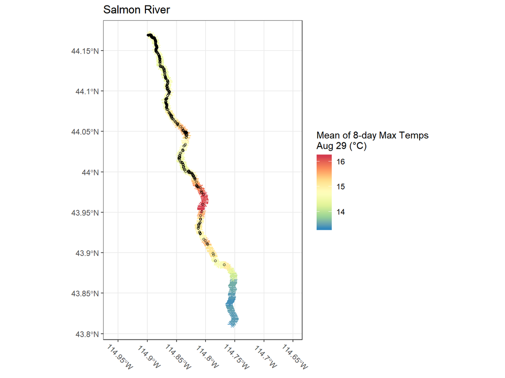

Figure 3.11: Map of Upper Salmon River (above Redfish Lake) showing modeled stream temperatures near the late summer spawning season for Chinook salmon and the distribution of redds (small, open black circles) available from redd surveys in recent years. Modeled temperatures are predictions for August 29 averaged across years where predictions are available.

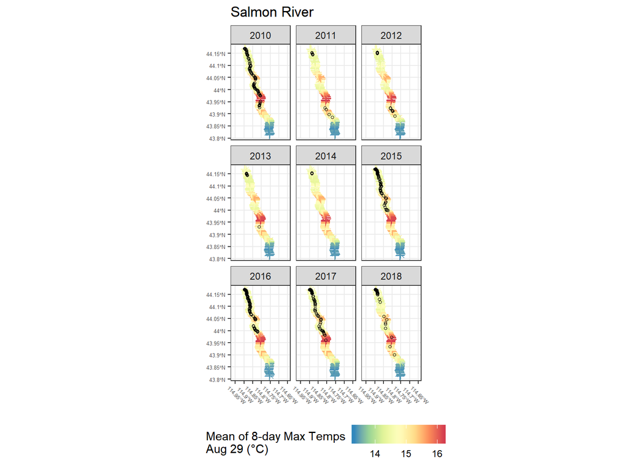

Figure 3.12: Same as figure above, except faceted by survey year to show years for which data are available and how the distribution of redds potentially changed.

Figure 3.13 provides a longitudinal temperature profile, in this case the mean of 8-day maximum temperature predictions for August 29, along with mean redd densities averaged across years for which survey data were available.

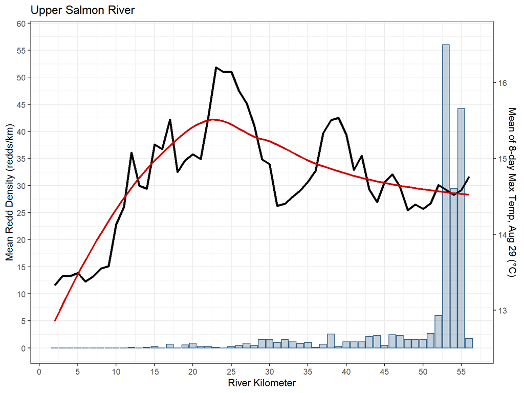

Figure 3.13: Mean redd density (redds/km) by river kilometer in the Upper Salmon River (above Redfish Lake Creek) averaged across years for which surveys were completed and data available. River kilometer 0 is the upstream extent of the mainstem Upper Salmon River at its source. River kilometer 56, the downstream extent, is at its confluence with Redfish Lake Creek. A longitudinal temperature profile, with smoothed line (red), showing predictions of the mean of 8-day maximum temperatures at August 29 (averaged across available years) is also shown.

### 3.3.2 Life Stage Specific Longitudinal Temperature Profiles

#### 3.3.2.1 Chinook salmon

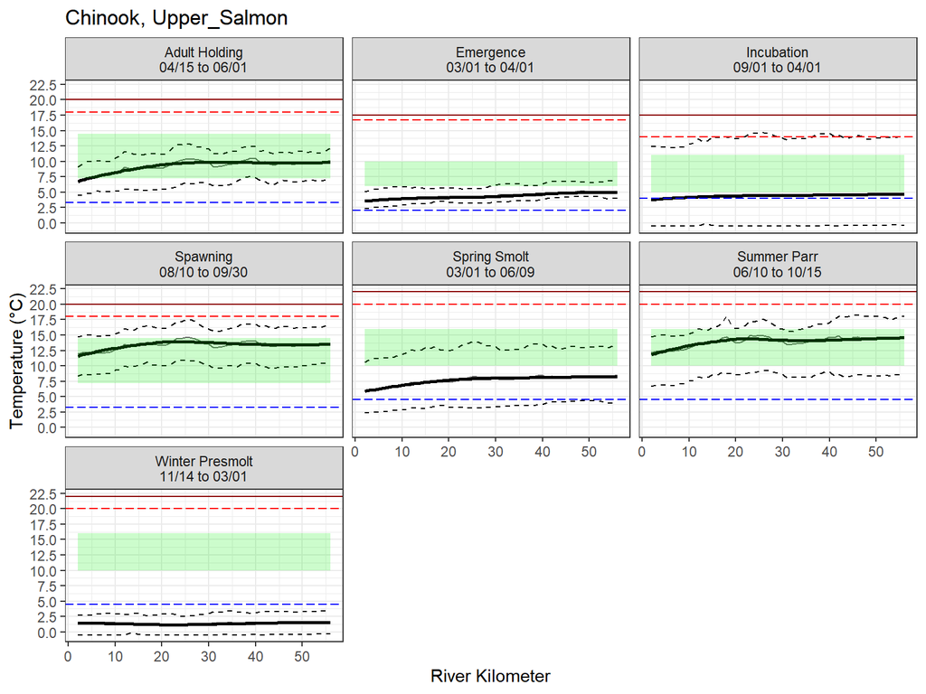

Figure 3.14: Longitudinal temperature profiles for the mainstem Upper Salmon River (above Redfish Lake Creek) faceted by Chinook salmon life stage. The bold black line shows the mean of 8-day max temperatures among dates within the life stage and dashed black lines show the minumum and maximum 8-day values among those dates. The green ribbon shows the optimum temperature range for that life stage whereas the blue line shows the minimum temperature threshold and the red dashed and solid lines show maximum and acute temperature thresholds, respectively, for each life stage.

#### 3.3.2.2 Steelhead

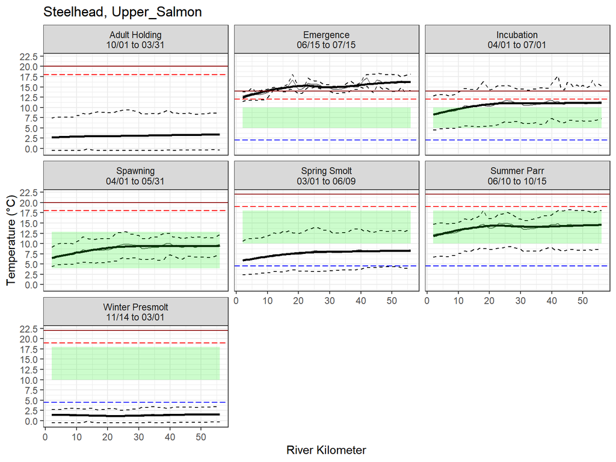

Figure 3.15: Longitudinal temperature profiles for the mainstem Upper Salmon River (above Redfish Lake Creek) faceted by steelhead life stage. The bold black line shows the mean of 8-day max temperatures among dates within the life stage and dashed black lines show the minumum and maximum 8-day values among those dates. The green ribbon shows the optimum temperature range for that life stage whereas the blue line shows the minimum temperature threshold and the red dashed and solid lines show maximum and acute temperature thresholds, respectively, for each life stage.

# 4 Discussion

## 4.1 Conclusions

# 5 Literature Cited

Carter, K. 2005. The effects of temperature on steelhead trout, Coho salmon, and Chinook salmon biology and function by life stage. Implications for Klamath Basin TMDLs. California Regional Water Quality Control Board. North Coast Region. 26 pp.

Idaho OSC Team (Idaho Governor’s Office of Species Conservation and partners). 2019. Upper Salmon Subbasin Habitat Integrated Rehabilitation Assessment. Assessment prepared for and with the U.S. Department of the Interior, Bureau of Reclamation. June 2019. 625 pp.

Isaak, D., S. Wenger, E. Peterson, J. Ver Hoef, D. Nagel, C. Luce, S. Hostetler, J. Dunham, B. Roper, S. Wollrab, G. Chandler, D. Horan, S. Parkes-Payne. 2017. The NorWeST summer stream temperature model and scenarios for the western U.S.: A crowd-sourced database and new geospatial tools foster a user community and predict broad climate warming of rivers and streams. Water Resources Research, 53:9181-9205. https://doi.org/10.1002/2017WR020969

McNyset, K.M., C.J. Volk, and C.E. Jordan. 2015. Developing an effective model for predicting spatially and temporally continuous stream temperatures from remotely sensed land surface temperatures. Water. 7:6827-6846.